# Syncing forks

While you’ve been working on your forked repository locally on your computer (ex: `remi-daigle/ohi-global`), there may be committed updates in the owner’s repository that is ‘upstream’ (ex: `OHI-Science/ohi-global`). To ensure that you are working with the most updated repository, you need to update your fork by creating a **pull request**. See some tips on process [here](https://github.com/OHI-Science/ohiprep/wiki/Using-GitHub#process).

## Updating your fork

To do this on the command line, see [help.github.com](https://help.github.com/articles/syncing-a-fork).

To do this through Github:

1. Go to the repository (‘repo’) belonging to the project owner ‘upstream’. In this example, the owner is called `OHI-Science` and the repo is `ohi-global`. Note that there are recent updates by user Melsteroni. To pull the most recent version of `ohi-global` from `OHI-Science`, click on the green button.

[figure not shown]

2. You will need to sync forks (the default is to sync branches).

[figure not shown]

3. Change the base fork to your repo: in this example it is `remi-daigle\ohi-global`. The head fork is the owner’s repo: `OHI-Science\ohi-global`. You can see those most recent commits by Melsteroni. Now you can click ‘Create pull request’.

[figure not shown]

**Note:**

- when the base fork and head fork are identified, we are in the forked repo `remi-daigle/ohi-global’. It is also possible to create a pull request the the head fork from this location.
- if that if you get an error *There isn’t anything to compare*, make sure you are still comparing forks, not branches.

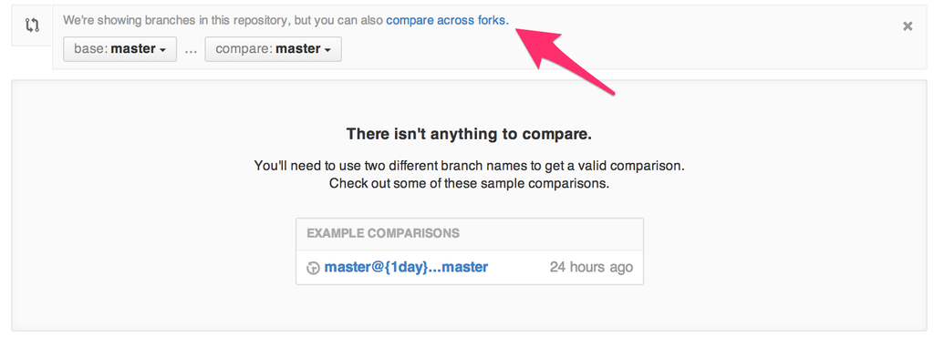

4. Enter a Title and a comment, when then allows you to click *Create pull request*

[figure not shown]

[figure not shown]

[figure not shown]

- to resolve these conflicts, follow instructions from [OHI-Science](https://github.com/OHI-Science/ohiprep/wiki/Using-GitHub#resolving-conflicts).
6. Once your repo on on github.com is has been updated, you can pull your updated fork to your workspace in RStudio either from the Git pulldown menu or from the Git tab.

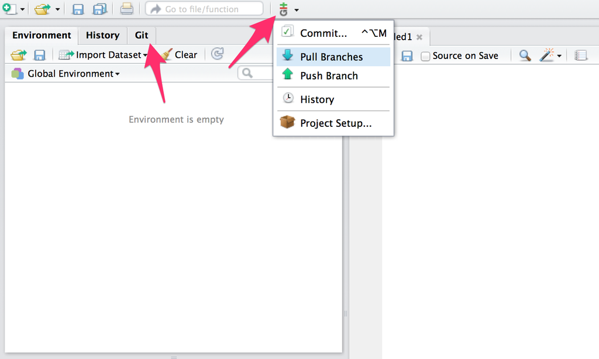